# # Project: TMDb Movies Data Analysis

- Introduction
- Data Wrangling
- Exploratory Data Analysis
- Conclusions

## Introduction

```python
import pandas as pd
import numpy as np
import matplotlib.pyplot as plt
import seaborn as sns
%matplotlib inline
```

## Data Wrangling

### General Properties

```python
df=pd.read_csv('tmdb-movies.csv')
df.head()
```

|  | id | imdb_id | popularity | budget | revenue | original_title | cast | homepage | director | tagline | ... | overview | runtime | genres | production_companies | release_date | vote_count | vote_average | release_year | budget_adj | revenue_adj |
| --- | --- | --- | --- | --- | --- | --- | --- | --- | --- | --- | --- | --- | --- | --- | --- | --- | --- | --- | --- | --- | --- |
| 0 | 135397 | tt0369610 | 32.985763 | 150000000 | 1513528810 | Jurassic World | Chris Pratt\|Bryce Dallas Howard\|Irrfan Khan\|Vi... | http://www.jurassicworld.com/ | Colin Trevorrow | The park is open. | ... | Twenty-two years after the events of Jurassic ... | 124 | Action\|Adventure\|Science Fiction\|Thriller | Universal Studios\|Amblin Entertainment\|Legenda... | 6/9/15 | 5562 | 6.5 | 2015 | 1.379999e+08 | 1.392446e+09 |
| 1 | 76341 | tt1392190 | 28.419936 | 150000000 | 378436354 | Mad Max: Fury Road | Tom Hardy\|Charlize Theron\|Hugh Keays-Byrne\|Nic... | http://www.madmaxmovie.com/ | George Miller | What a Lovely Day. | ... | An apocalyptic story set in the furthest reach... | 120 | Action\|Adventure\|Science Fiction\|Thriller | Village Roadshow Pictures\|Kennedy Miller Produ... | 5/13/15 | 6185 | 7.1 | 2015 | 1.379999e+08 | 3.481613e+08 |
| 2 | 262500 | tt2908446 | 13.112507 | 110000000 | 295238201 | Insurgent | Shailene Woodley\|Theo James\|Kate Winslet\|Ansel... | http://www.thedivergentseries.movie/#insurgent | Robert Schwentke | One Choice Can Destroy You | ... | Beatrice Prior must confront her inner demons ... | 119 | Adventure\|Science Fiction\|Thriller | Summit Entertainment\|Mandeville Films\|Red Wago... | 3/18/15 | 2480 | 6.3 | 2015 | 1.012000e+08 | 2.716190e+08 |
| 3 | 140607 | tt2488496 | 11.173104 | 200000000 | 2068178225 | Star Wars: The Force Awakens | Harrison Ford\|Mark Hamill\|Carrie Fisher\|Adam D... | http://www.starwars.com/films/star-wars-episod... | J.J. Abrams | Every generation has a story. | ... | Thirty years after defeating the Galactic Empi... | 136 | Action\|Adventure\|Science Fiction\|Fantasy | Lucasfilm\|Truenorth Productions\|Bad Robot | 12/15/15 | 5292 | 7.5 | 2015 | 1.839999e+08 | 1.902723e+09 |
| 4 | 168259 | tt2820852 | 9.335014 | 190000000 | 1506249360 | Furious 7 | Vin Diesel\|Paul Walker\|Jason Statham\|Michelle ... | http://www.furious7.com/ | James Wan | Vengeance Hits Home | ... | Deckard Shaw seeks revenge against Dominic Tor... | 137 | Action\|Crime\|Thriller | Universal Pictures\|Original Film\|Media Rights ... | 4/1/15 | 2947 | 7.3 | 2015 | 1.747999e+08 | 1.385749e+09 |

5 rows × 21 columns

```python
df.shape
```

```
(10866, 21)
```

```python
df.describe()
```

|  | id | popularity | budget | revenue | runtime | vote_count | vote_average | release_year | budget_adj | revenue_adj |
| --- | --- | --- | --- | --- | --- | --- | --- | --- | --- | --- |
| count | 10866.000000 | 10866.000000 | 1.086600e+04 | 1.086600e+04 | 10866.000000 | 10866.000000 | 10866.000000 | 10866.000000 | 1.086600e+04 | 1.086600e+04 |
| mean | 66064.177434 | 0.646441 | 1.462570e+07 | 3.982332e+07 | 102.070863 | 217.389748 | 5.974922 | 2001.322658 | 1.755104e+07 | 5.136436e+07 |
| std | 92130.136561 | 1.000185 | 3.091321e+07 | 1.170035e+08 | 31.381405 | 575.619058 | 0.935142 | 12.812941 | 3.430616e+07 | 1.446325e+08 |
| min | 5.000000 | 0.000065 | 0.000000e+00 | 0.000000e+00 | 0.000000 | 10.000000 | 1.500000 | 1960.000000 | 0.000000e+00 | 0.000000e+00 |
| 25% | 10596.250000 | 0.207583 | 0.000000e+00 | 0.000000e+00 | 90.000000 | 17.000000 | 5.400000 | 1995.000000 | 0.000000e+00 | 0.000000e+00 |
| 50% | 20669.000000 | 0.383856 | 0.000000e+00 | 0.000000e+00 | 99.000000 | 38.000000 | 6.000000 | 2006.000000 | 0.000000e+00 | 0.000000e+00 |
| 75% | 75610.000000 | 0.713817 | 1.500000e+07 | 2.400000e+07 | 111.000000 | 145.750000 | 6.600000 | 2011.000000 | 2.085325e+07 | 3.369710e+07 |
| max | 417859.000000 | 32.985763 | 4.250000e+08 | 2.781506e+09 | 900.000000 | 9767.000000 | 9.200000 | 2015.000000 | 4.250000e+08 | 2.827124e+09 |

```python
df.info()
```

```
<class 'pandas.core.frame.DataFrame'>
RangeIndex: 10866 entries, 0 to 10865
Data columns (total 21 columns):
 #   Column                Non-Null Count  Dtype
---  ------                --------------  -----
 0   id                    10866 non-null  int64
 1   imdb_id               10856 non-null  object
 2   popularity            10866 non-null  float64
 3   budget                10866 non-null  int64
 4   revenue               10866 non-null  int64
 5   original_title        10866 non-null  object
 6   cast                  10790 non-null  object
 7   homepage              2936 non-null   object
 8   director              10822 non-null  object
 9   tagline               8042 non-null   object
 10  keywords              9373 non-null   object
 11  overview              10862 non-null  object
 12  runtime               10866 non-null  int64
 13  genres                10843 non-null  object
 14  production_companies  9836 non-null   object
 15  release_date          10866 non-null  object
 16  vote_count            10866 non-null  int64
 17  vote_average          10866 non-null  float64
 18  release_year          10866 non-null  int64
 19  budget_adj            10866 non-null  float64
 20  revenue_adj           10866 non-null  float64
dtypes: float64(4), int64(6), object(11)
memory usage: 1.7+ MB
```

```python
df.isnull().sum()
```

```
id                         0
imdb_id                   10
popularity                 0
budget                     0
revenue                    0
original_title             0
cast                      76
homepage                7930
director                  44
tagline                 2824
keywords                1493
overview                   4
runtime                    0
genres                    23
production_companies    1030
release_date               0
vote_count                 0
vote_average               0
release_year               0
budget_adj                 0
revenue_adj                0
dtype: int64
```

### Data Cleaning (handling unused & missing values)

[figure not shown]

```python
df.hist(figsize=(10,8));
```

```python
#Deleting the columns that is not required
# list of columns that are to be deleted/dropped

df.drop(['imdb_id','cast','homepage','director','tagline','keywords','overview','production_companies'],axis=1,inplace=True)
```

```python
df.info()
```

```
<class 'pandas.core.frame.DataFrame'>
RangeIndex: 10866 entries, 0 to 10865
Data columns (total 13 columns):
 #   Column          Non-Null Count  Dtype
---  ------          --------------  -----
 0   id              10866 non-null  int64
 1   popularity      10866 non-null  float64
 2   budget          10866 non-null  int64
 3   revenue         10866 non-null  int64
 4   original_title  10866 non-null  object
 5   runtime         10866 non-null  int64
 6   genres          10843 non-null  object
 7   release_date    10866 non-null  object
 8   vote_count      10866 non-null  int64
 9   vote_average    10866 non-null  float64
 10  release_year    10866 non-null  int64
 11  budget_adj      10866 non-null  float64
 12  revenue_adj     10866 non-null  float64
dtypes: float64(4), int64(6), object(3)
memory usage: 1.1+ MB
```

```python
#the count of zeros in the budget and revenue columns
df[['budget','revenue','release_year']].groupby('release_year').count()
```

| release_year | budget | revenue |
| --- | --- | --- |
| 1960 | 32 | 32 |
| 1961 | 31 | 31 |
| 1962 | 32 | 32 |
| 1963 | 34 | 34 |
| 1964 | 42 | 42 |
| 1965 | 35 | 35 |
| 1966 | 46 | 46 |
| 1967 | 40 | 40 |
| 1968 | 39 | 39 |
| 1969 | 31 | 31 |
| 1970 | 41 | 41 |
| 1971 | 55 | 55 |
| 1972 | 40 | 40 |
| 1973 | 55 | 55 |
| 1974 | 47 | 47 |
| 1975 | 44 | 44 |
| 1976 | 47 | 47 |
| 1977 | 57 | 57 |
| 1978 | 65 | 65 |
| 1979 | 57 | 57 |
| 1980 | 78 | 78 |
| 1981 | 82 | 82 |
| 1982 | 81 | 81 |
| 1983 | 80 | 80 |
| 1984 | 105 | 105 |
| 1985 | 109 | 109 |
| 1986 | 121 | 121 |
| 1987 | 125 | 125 |
| 1988 | 145 | 145 |
| 1989 | 137 | 137 |
| 1990 | 132 | 132 |
| 1991 | 133 | 133 |
| 1992 | 133 | 133 |
| 1993 | 178 | 178 |
| 1994 | 184 | 184 |
| 1995 | 175 | 175 |
| 1996 | 204 | 204 |
| 1997 | 192 | 192 |
| 1998 | 210 | 210 |
| 1999 | 224 | 224 |
| 2000 | 227 | 227 |
| 2001 | 242 | 242 |
| 2002 | 266 | 266 |
| 2003 | 281 | 281 |
| 2004 | 307 | 307 |
| 2005 | 364 | 364 |
| 2006 | 408 | 408 |
| 2007 | 438 | 438 |
| 2008 | 496 | 496 |
| 2009 | 533 | 533 |
| 2010 | 490 | 490 |
| 2011 | 540 | 540 |
| 2012 | 588 | 588 |
| 2013 | 659 | 659 |
| 2014 | 700 | 700 |
| 2015 | 629 | 629 |

```python
#drop zeros
df.drop(df[df['revenue']==0].index,inplace=True)
```

```python
#show the number of rows after drop zeros
df.shape
```

```
(4850, 13)
```

```python
# i decided to drop all the missing values in geners rows
df.dropna(inplace=True)
df.info()
```

```
<class 'pandas.core.frame.DataFrame'>
Int64Index: 4850 entries, 0 to 10848
Data columns (total 13 columns):
 #   Column          Non-Null Count  Dtype
---  ------          --------------  -----
 0   id              4850 non-null   int64
 1   popularity      4850 non-null   float64
 2   budget          4850 non-null   int64
 3   revenue         4850 non-null   int64
 4   original_title  4850 non-null   object
 5   runtime         4850 non-null   int64
 6   genres          4850 non-null   object
 7   release_date    4850 non-null   object
 8   vote_count      4850 non-null   int64
 9   vote_average    4850 non-null   float64
 10  release_year    4850 non-null   int64
 11  budget_adj      4850 non-null   float64
 12  revenue_adj     4850 non-null   float64
dtypes: float64(4), int64(6), object(3)
memory usage: 530.5+ KB
```

```python
#Delete duplicate rows in the dataset
df.duplicated().sum()
```

```
1
```

```python
df.drop_duplicates(inplace=True)
df.shape
```

```
(4849, 13)
```

```python
#change budget and revenue into integer
df['budget'] = df['budget'].astype(int)
df['revenue'] = df['revenue'].astype(int)
```

## Exploratory Data Analysis

### Question 1 (Which years do movies have the Highest budget?)

```python
#we going to group total budget by each years
budget_yr = df.groupby('release_year')['budget'].sum()
budget_yr.tail(10)
```

```
release_year
2006    6914218000
2007    6954567892
2008    7117556800
2009    7537827919
2010    8463138439
2011    8441550543
2012    7587610525
2013    8567922778
2014    7393768000
2015    7170777528
Name: budget, dtype: int64
```

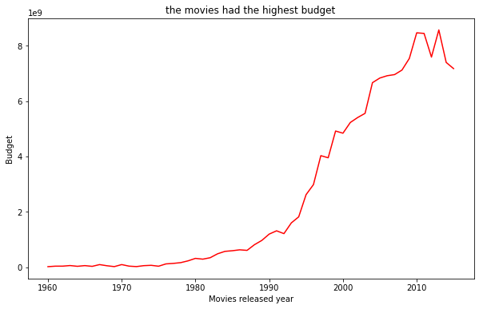

```python
#plot
budget_yr.plot(figsize = (10,6), color="red")
plt.xlabel('Movies released year')
plt.ylabel('Budget')
plt.title('the movies had the highest budget');
```

##### we can see that the last 10 years movies have the highest budget than other old years

```python
#first we're going to creat a new column called 'profit'
df['profit'] =df['revenue'] - df['budget']

df['revenue'] = df['revenue'].astype(int)
df.head(1)
```

|  | id | popularity | budget | revenue | original_title | runtime | genres | release_date | vote_count | vote_average | release_year | budget_adj | revenue_adj | profit |
| --- | --- | --- | --- | --- | --- | --- | --- | --- | --- | --- | --- | --- | --- | --- |
| 0 | 135397 | 32.985763 | 150000000 | 1513528810 | Jurassic World | 124 | Action\|Adventure\|Science Fiction\|Thriller | 6/9/15 | 5562 | 6.5 | 2015 | 1.379999e+08 | 1.392446e+09 | 1363528810 |

```python
# find average
df['profit'].mean()
```

```
59669246.81604455
```

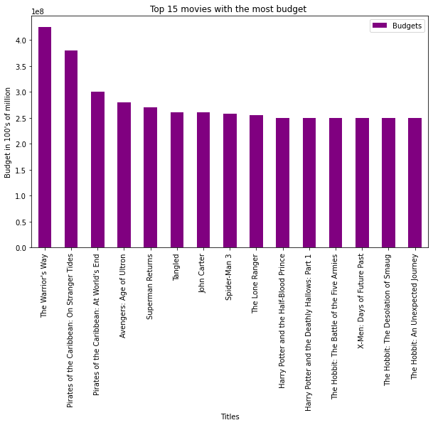

```python
top_movies_budget = df['budget'].sort_values(ascending=False)[:15]
high_budget=pd.DataFrame()
titles_exp=[]
budgets=[]
for i in top_movies_budget.index:
    titles_exp.append(df.loc[i,'original_title'])
    budgets.append(top_movies_budget.loc[i])
high_budget['Titles']=titles_exp
high_budget['Budgets']=budgets
high_budget.set_index('Titles',inplace=True)
high_budget.plot(kind ='bar',figsize=(10,6), color='purple')
plt.title('Top 15 movies with the most budget ');
plt.ylabel('Budget in 100\'s of million');
```

#### we can obviously see that the Warrior's Way movie has the highest budget

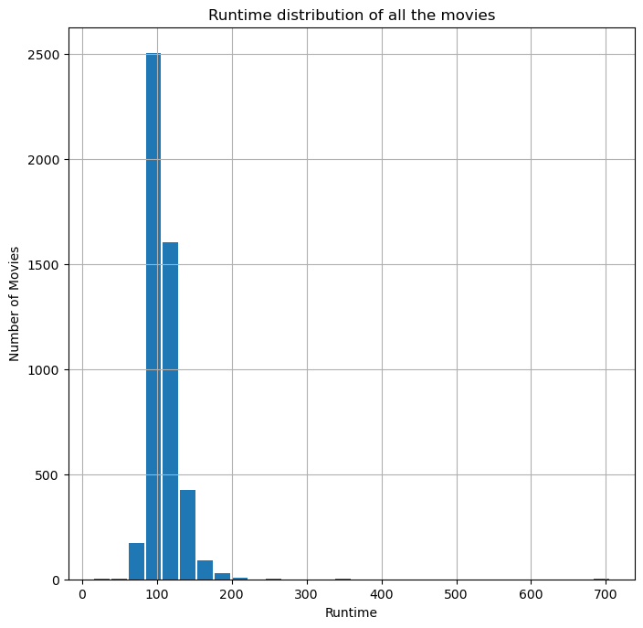

```python
# Create a histogram for movie runtimes.
plt.figure(figsize=(8,8), dpi=100)
df['runtime'].hist(rwidth = 0.9, bins =30)
plt.xlabel('Runtime')
plt.ylabel('Number of Movies')
plt.title('Runtime distribution of all the movies');
```

## Conclusions

#### Limitaions:

##### there are many droped rows contained 0 values and null values.

##### The dataset was cut by few thousand rows of movies, which would definitly affect the result.

##### the budget and revenue column do not have currency unit, it might be possible different movies have budget in different currency according to the country they are produce in.